# Vespa crabro: Differential Gene Expression Analysis

Emeline Favreau

04/12/2020

Copyright 2020 Emeline Favreau, University College London.

### Analysis steps:

- Obtaining data
- Formatting data
- Aim 1: Run DESeq2 on all samples
- Aim 2: Run DESeq2 on female samples
- Aim 3: Run DESeq2 on female samples (no queen)
- Aim 4: Compare DEG and positive selection

### Aim 1: Run DESeq2 on all samples

I first check potential sample outliers looking at normalised read counts (with a heatmap, a sample-to-sample dendogram, a PCA) and a barplot of DEG value ranges.

```
## -- replacing outliers and refitting for 448 genes
## -- DESeq argument 'minReplicatesForReplace' = 7
## -- original counts are preserved in counts(dds)
```

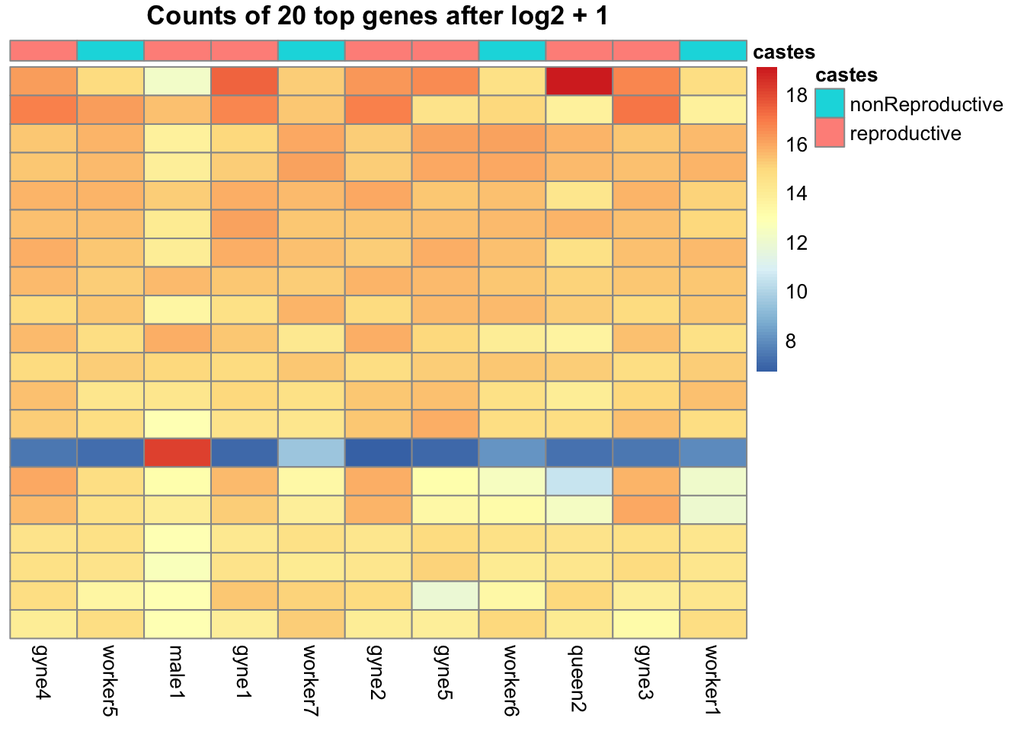

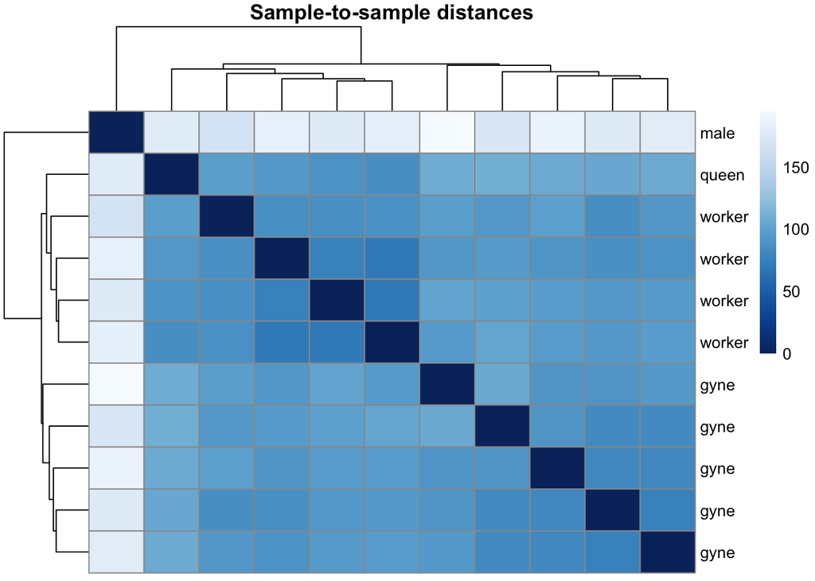

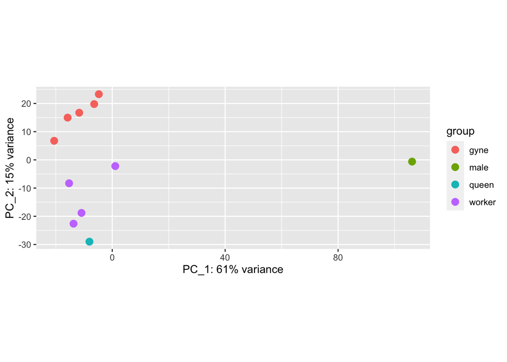

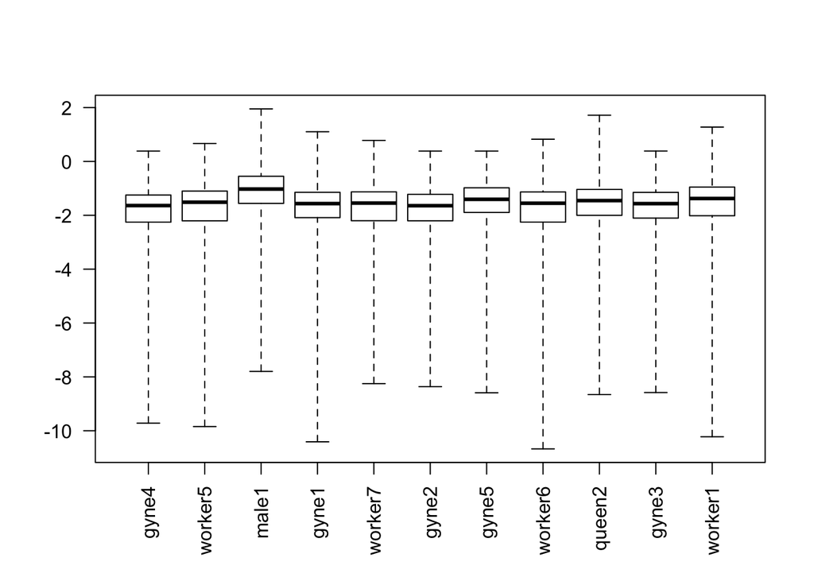

The data including the male show clear difference between male and the other samples. So I will remove this outlier sample and only use worker/gyne/queen.

### Aim 2: Run DESeq2 on female samples

I first check potential sample outliers looking at normalised read counts (with a heatmap, a sample-to-sample dendogram, a PCA).

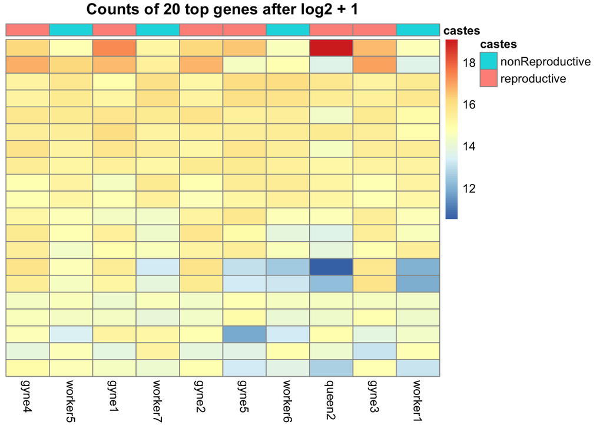

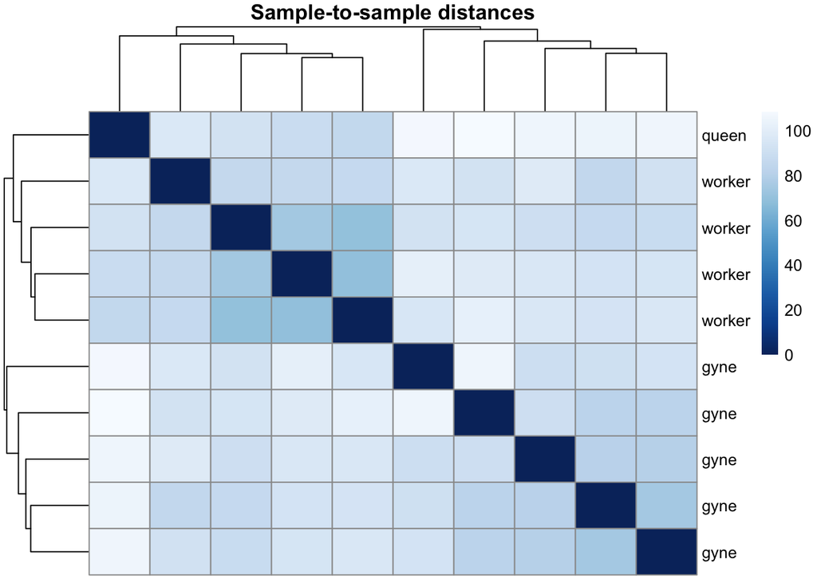

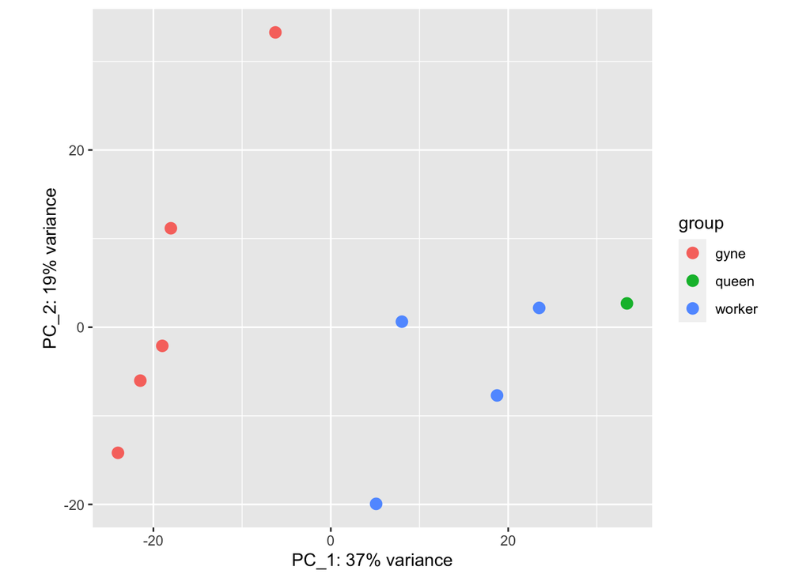

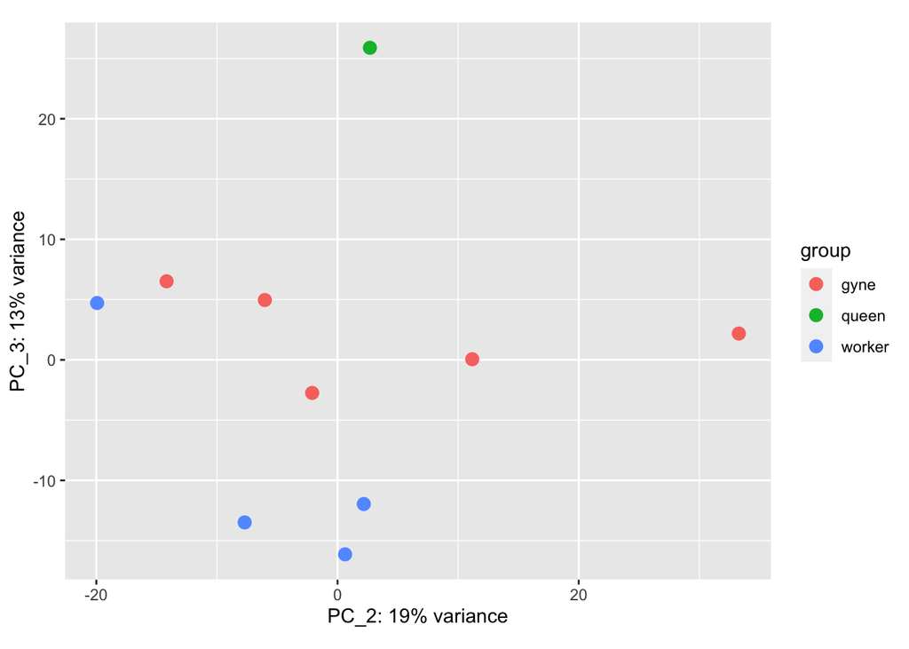

There are 511 genes that are significantly differentially expressed between reproductives and non-reproductives.

Because queen sample is unique and rather different than the rest of the data, I re-run the analysis without the queen, and looking for genes that are differentially expressed between workers and gynes.

### Aim 3: Run DESeq2 on female samples without the queen

I first check sample outliers looking at normalised read counts (with a heatmap, a sample-to-sample dendogram, a PCA) and a barplot of DEG value ranges.

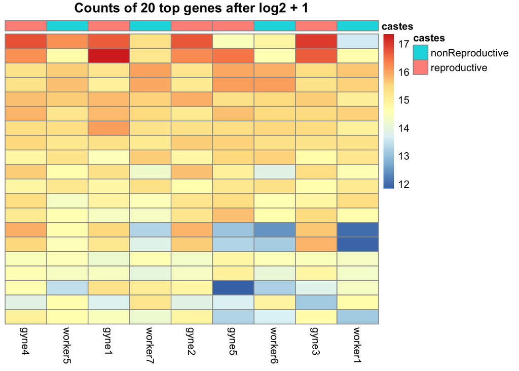

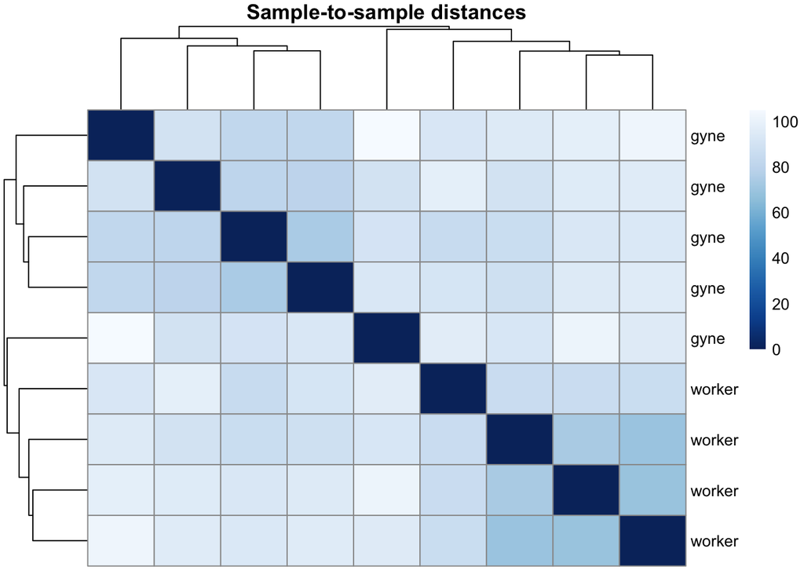

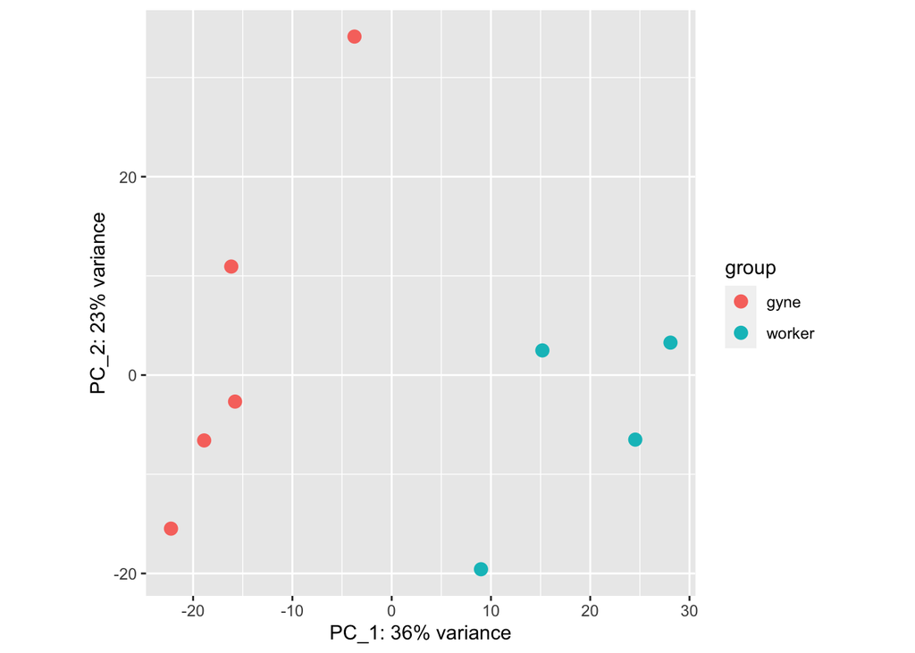

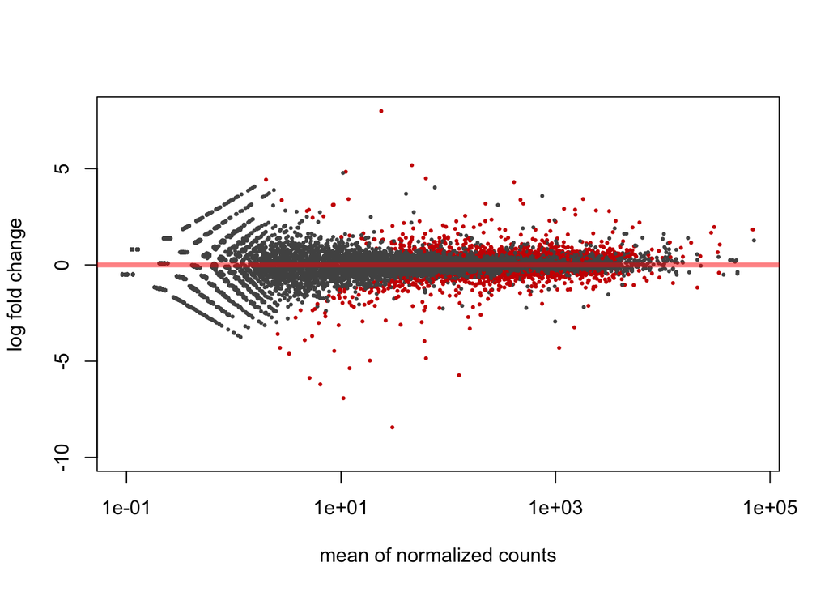

### Aim 4: Compare DEG and positive selection

For this analysis, I compare workers versus gynes, excluding outlier queen and male samples.

### Notes:

- Based on a script from Ben Taylor (BT)
- BT: “the way DESeq2 handles effects in the formula depends on if they’re numeric or factors (like a regular LM). If a factor, DESeq2 will take the first factor level as a reference level and will compare the expression each other factor level against the reference separately. If a numeric, then DESeq2 looks for genes whose expression correlates significantly with the value of the numeric. Note that this means that you need to be careful with mixing numeric variables with fold changes- for example, in the data I’ve given you, the formula ‘~ovaries’ won’t return any DEGs if combined with a LFC threshold, because it will assume you’re looking for a given fold change for each integer change in ovarian size (which obviously won’t be the case since ovarian values range in the hundreds). So, if you want to check for fold changes of a numeric variable, you’ll want to normalize that variable either by scaling it or by setting the upper limit of the range as 1 and the lower limit as 0”
- BT: “I used to use a threshold of 20 reads in at least one cohort of samples for the cleaning of the gene count data, but I’ve since updated the threshold to be equal to 1 count/sample for each cohort”

DESeq2 tutorial: https://bioconductor.org/packages/release/bioc/vignettes/DESeq2/inst/doc/DESeq2.html#standard-workflow